# Assignment 4

## Problem 1

## Explain to your students

We present two figures which will demonstrate how \(\hat{\beta}\) can converge to both a point and a distribution:

- The first plot demonstrates how \(\hat{\beta}\) converges in probability to \(\beta\) as \(n\) becomes large.
- The second plot shows how the distribution of \(\hat{\beta}\) converges to a normal distribution centered on \(\beta\) as \(n\) becomes large.

## Convergence Plot

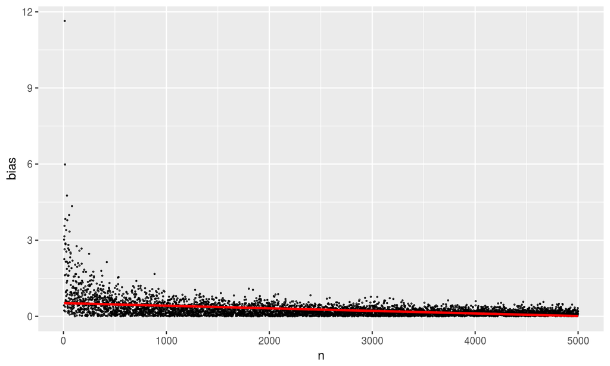

As we can see, the absolute value of the bias trends towards zero as \(n\) becomes increasingly large.

## Asymptotic Distribution

Our estimated coefficients will be asymptotically normally distributed. This means that, regardless of the sample size \(N\) we are using now, because our coefficient is a ratio of averages, we can represent our coefficient as being drawn from a normally distributed population centered at the true \(\beta\) with variance \(\frac{1}{N} \widehat{V}_{\beta}^0\).

## Asymptotic Distribution

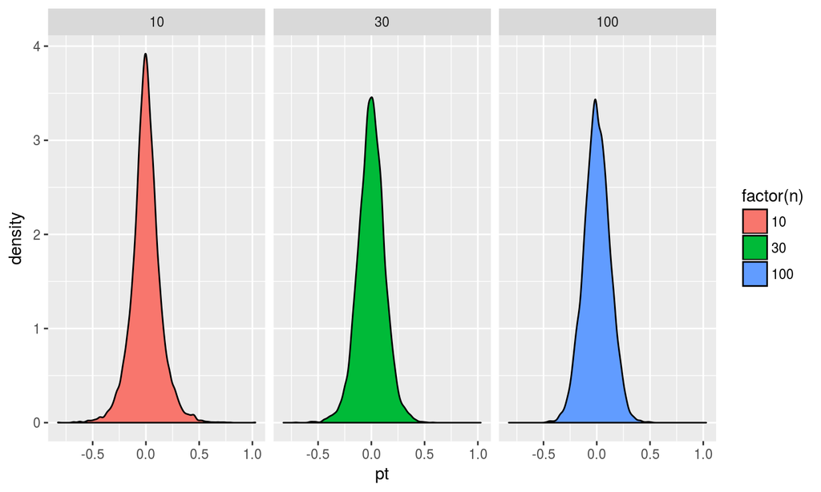

These plots show that the difference between \(\hat{\beta}\) and \(\beta\) is centered at zero and normally distributed, starting at very low levels of \(N\).

## Problem 2

## Summary Statistics

We can see that the mean and standard deviation of the two samples we have drawn are very different between the two distributions we choose for our errors. The errors drawn from the normal distribution lead to a mean of our estimator close to our true \(\beta\). The Cauchy errors result in a mean much further away from the true value and have a larger standard deviation.

Table 1: Summary Statistics by Error Distribution

|  | Mean | S.D. |
| --- | --- | --- |
| Cauchy | 2.216 | 1.093 |
| Normal | 0.308 | 0.013 |

## Cauchy Plot

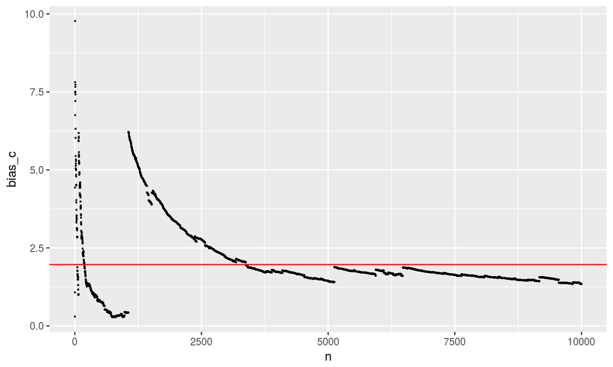

## Normal Plot

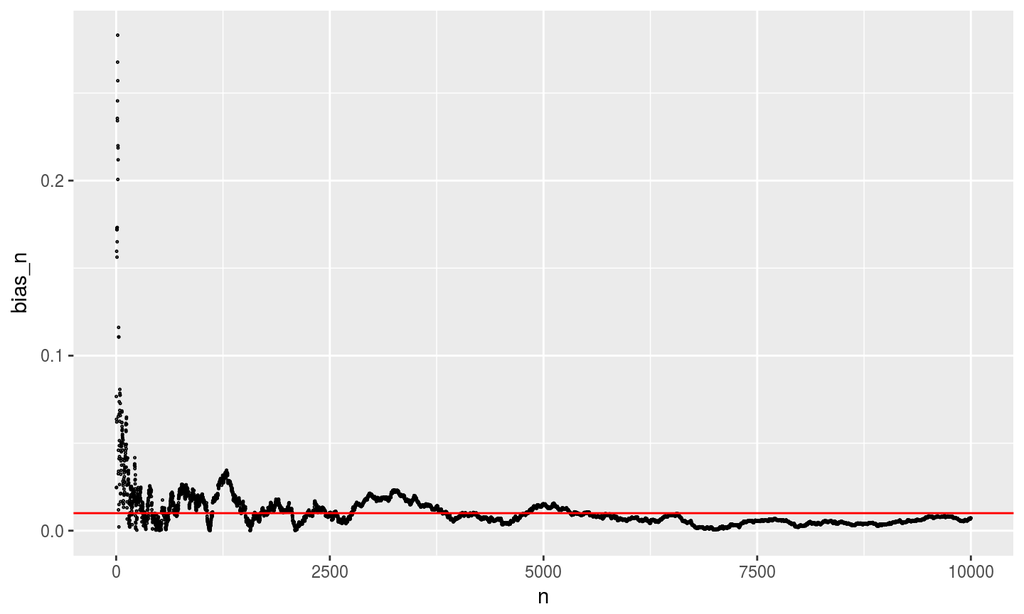

## Conclusion

When looking at the Cauchy distributed error terms, we can see large jumps for the \(\hat{\beta}\) estimate. These jumps come from the large outliers in the error term. The Cauchy distribution is characterized by having no defined moments and large outliers. These outliers will greatly impact the accuracy of our estimation as we see in the figure.

For the normally distributed errors we see a steady decrease in the volitility of the \(\hat{\beta}\) estimates as \(n\) increases. This is consistent with theory.